# Auto Question Generation for Supervised learning classification problem

Author

©AksharaPlus LLC

Published

June 12, 2025

# 1 System Workflow for Question Generation and Answer Processing

## 1.1 Machine Learning Syllabus Overview

This section outlines the topics and subtopics covered in the AI Tutor system, organized in a hierarchical structure.

## 1.2 Topics and Subtopics:

- **Logistic Regression**
  - Introduction
  - Mathematical Foundation
  - Cost Function and Optimization
  - Regularization
  - Multiclass Logistic Regression
  - Implementation
- **k-Nearest Neighbors**
  - Introduction
  - Distance Metrics
  - Choosing k
  - Algorithm Mechanics
  - Scaling and Normalization
  - Implementation
- **Random Forest**
  - Introduction
  - Bootstrap Aggregation
  - Feature Randomness
  - Voting and Averaging
  - Hyperparameters
  - Implementation
- **Decision Trees**
  - Introduction
  - Splitting Criteria
  - Tree Construction
  - Pruning
  - Prediction
  - Implementation
- **Naïve Bayes**
  - Introduction
  - Probability Basics
  - Gaussian Naïve Bayes
  - Multinomial Naïve Bayes
  - Bernoulli Naïve Bayes
  - Implementation
- **Support Vector Machines**
  - Introduction
  - Linear SVM
  - Kernel Trick
  - Mathematical Foundation
  - Regularization and Cost
  - Implementation`

### 1. Question Categories and Templates

The system supports various question types, each with a specific template. Below is the flowchart for selecting and generating a question based on the template type.

```
flowchart TD
    A[Start: User Selects Topic, Subtopic, Difficulty] --> B[Generate Question: template_ques_gen.py]

    B --> B1[Select Random Question Template]
    B1 --> B2["Fill Template with Parameters e.g., n points, w weights, p probability"]
    B2 --> B3{Categorize Question Type}

    B3 -->|Formula-Based| B4["Template: If P(y=0) = {p}, what’s P(y=1) in {topic}?"]
    B4 --> B5["Generate Parameters: p, topic"]
    B5 --> B6[No Visual Data Needed]

    B3 -->|Plot-Based| B7["Template: Based on the scatter plot below with {n} points, critique {topic}’s performance."]
    B7 --> B8["Generate Scatter Plot Data: n points, separable or not"]
    B8 --> B9[Plot Scatter: Class 0 Blue, Class 1 Red]

    B3 -->|Table-Based| B10["Template: In the data table below with {m} samples, why prefer {topic} over {alternative}?"]
    B10 --> B11["Generate Data Table: m samples, f features"]

    B3 -->|Line-Plot-Based| B12["Template: If the line graph below shows noise {p}, how does {topic} adjust?"]
    B12 --> B13["Generate Line Plot Data: noise level p"]
    B13 --> B14[Plot Line Graph: Noise vs. Performance]

    B3 -->|Theoretical| B15["Template: Compare {topic} and {model} for {task} based on {dimension}."]
    B15 --> B16[No Visual Data Needed]

    B3 -->|Conceptual| B17["Template: How does gradient descent update {topic}’s {parameter} in {scenario}?"]
    B17 --> B18[No Visual Data Needed]

    B3 -->|Implementation| B19["Template: What’s the role of scikit-learn in {topic}’s {task}?"]
    B19 --> B20[No Visual Data Needed]

    B6 --> C[Output: Display Question and Plot/Table if Applicable]
    B9 --> C
    B11 --> C
    B14 --> C
    B16 --> C
    B18 --> C
    B20 --> C
```

### 2. SLM+RAG Workflow for Theoretical Questions

This section outlines the workflow for generating theoretical answers using a Retrieval-Augmented Generation (RAG) pipeline, with Wikipedia as the data source.

```
graph TD
    A[User Query<br>e.g., 'What is logistic regression?'] -->|Input| B[RAG Pipeline]

    subgraph B[RAG Pipeline]
        direction LR
        C[Retriever] -->|Retrieves| E[Knowledge Base]
        D[Generator] -->|Generates| F[Generated Answer]
        C -->|Provides Context| D
    end

    subgraph C[Retriever]
        C1[Sentence-BERT<br>Semantic Embeddings] --> C2[FAISS Index<br>L2 Similarity Search]
    end

    subgraph D[Generator]
        D1[TinyLLaMA<br>1.1B Parameters<br>Text Generation]
    end

    subgraph E[Knowledge Base]
        E1[108 Topics<br>Wikipedia]
        E2[Preprocessed Chunks]
        E3[JSON Format]
    end

    subgraph F[Generated Answer]
        F1[e.g., 'Logistic regression is a statistical...']
    end

    B -->|Output| F

    style A fill:#dfd,stroke:#333,stroke-width:2px
    style B fill:#bbf,stroke:#333,stroke-width:2px
    style C fill:#bbf,stroke:#333
    style D fill:#bbf,stroke:#333
    style E fill:#bbf,stroke:#333
    style F fill:#dfd,stroke:#333,stroke-width:2px
    style C1 fill:#e6f,stroke:#333
    style C2 fill:#e6f,stroke:#333
    style D1 fill:#e6f,stroke:#333
    style E1 fill:#e6f,stroke:#333
    style E2 fill:#e6f,stroke:#333
    style E3 fill:#e6f,stroke:#333
    style F1 fill:#e6f,stroke:#333
```

### 3. Scatter Plot Question Answer Generation Workflow

This section details the workflow for answering scatter plot-based questions, such as “Based on the scatter plot below with {n} points, critique {topic}’s performance.”

```
flowchart TD
    A["Start: Scatter Plot Question with n Points"] --> B[Extract Plot Data: answer_scatter.py]

    B --> B1[Parse Data: X, y, separable Flag]
    B1 --> B2[Visual Analysis: Compute Overlap and Clustering]
    B2 --> B3[Overlap: Minimal, Slight, Significant<br>Clustering: Tight, Spread Out]
    B3 --> B4["Determine Visual Effectiveness of {topic}"]

    B4 --> C["Programmatic Analysis: Evaluate {topic}"]
    C --> C1[Fit Model: e.g., Logistic Regression, SVM]
    C1 --> C2[Compute Metrics: Accuracy, F1, Precision]
    C2 --> C3[Compute Decision Boundary: Slope, Intercept]

    C --> D[Compare Algorithms: Find Best Performer]
    D --> D1[Evaluate All: Logistic Regression, SVM, Naïve Bayes, etc.]
    D1 --> D2[Select Best Algorithm: Highest F1 Score]
    D2 --> D3[Compute Best Algorithm's Decision Boundary]

    C3 --> E[Generate Visualizations]
    D3 --> E
    E --> E1["Plot Side-by-Side: {topic} vs. Best Algorithm"]
```

## 1.3 2. Advanced AI Tutor Capabilities: Qwen Model Integration and Enhanced Question Generation (Current Phase)

This section describes the recent advancements in the AI Tutor system, focusing on the integration of the Qwen Small Language Model (SLM), its fine-tuning process, the enhanced Retrieval-Augmented Generation (RAG) for theoretical questions, and the development of a Gradio application for generating Fill-in-the-Blank (FIB) and Multiple-Choice Questions (MCQ).

### 2.1 Overall System Architecture

The updated system architecture leverages a fine-tuned Qwen model for advanced natural language understanding and generation, integrating seamlessly with knowledge retrieval and interactive user interfaces.

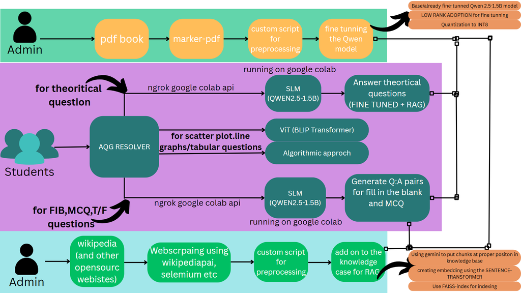

Figure 1: AI Tutor System Architecture Diagram

Figure Figure 1 illustrates the comprehensive architecture, highlighting the flow from data ingestion to user interaction with the SLM for various question types.

### 2.2 Fine-Tuning the Qwen Model

To enable the Qwen SLM to excel in machine learning domain-specific tasks and generate high-quality educational content, it underwent a **fine-tuning** process using domain-relevant data.

#### Approach to Fine-Tuning:

1. **Base Model Selection:** We selected `Qwen/Qwen2.5-1.5B-Instruct` as the base model. This model offers a good balance between performance and computational requirements, making it suitable for deployment in environments like Google Colab. Its “Instruct” variant is pre-trained for instruction following, which is beneficial for question generation tasks.
2. **Dataset Preparation:** A crucial step involved curating a dataset of machine learning concepts, definitions, and relationships. This dataset was formatted into prompt-response pairs suitable for instruction tuning. The data included theoretical explanations, comparisons, and structural information relevant to various machine learning topics.
3. **Low-Rank Adaptation (LoRA):** Instead of full fine-tuning (which is computationally intensive and requires significant GPU memory), we employed **LoRA (Low-Rank Adaptation)**. LoRA freezes the pre-trained model weights and injects small, trainable rank-decomposition matrices into each layer of the Transformer architecture. This significantly reduces the number of trainable parameters, making fine-tuning more efficient in terms of memory and compute, while achieving comparable performance to full fine-tuning.
4. **Training Environment:** The fine-tuning was performed within Google Colab, leveraging its GPU resources. The `peft` (Parameter-Efficient Fine-tuning) library was used to manage the LoRA adapters, and `bitsandbytes` was utilized for 8-bit quantization.
5. **Quantization (`bitsandbytes`):** To further optimize memory usage and accelerate inference, the base Qwen model was loaded in 8-bit precision using `bitsandbytes`. This technique reduces the memory footprint of the model weights, allowing larger models to fit into limited GPU memory and speeding up computations, which is critical for real-time generation in the Gradio app.

The fine-tuned model (`lora_model.pth`) effectively specializes the Qwen model on machine learning knowledge, enabling it to generate precise and contextually relevant responses.

### 2.3 Integration with Retrieval-Augmented Generation (RAG)

The fine-tuned Qwen model is integrated into a RAG pipeline for generating theoretical answers, enhancing its ability to provide accurate and contextually rich responses.

#### Approach to RAG Integration:

1. **Knowledge Base (KB) Enhancement:** The existing knowledge base (`rephrased_data.json`) was further structured to explicitly include `topic`, `subtopic`, and `difficulty level` information for each chunk of text. This granular tagging is crucial for the new retrieval mechanism.
2. **Model Loading (`load_qwen_local`):**
   - The `AutoTokenizer` and `AutoModelForCausalLM` from the `transformers` library are used to load the base Qwen model.
   - The `BitsAndBytesConfig` is applied during base model loading to enable 8-bit quantization, optimizing memory.
   - The `PeftModel.from_pretrained` method then efficiently loads the LoRA adapters on top of the quantized base model, effectively creating the fine-tuned RAG generator.
   - A `pipeline` from `transformers` is then configured for `text-generation`, bundling the model and tokenizer for easy inference.
3. **Context-Driven Generation (`generate_question`):**
   - The RAG pipeline operates by first retrieving relevant information from the knowledge base before generating a question.
   - **Retrieval Mechanism (Updated):** Unlike the previous semantic search (`Sentence-BERT` + `FAISS`), the current approach for theoretical answers and new question types leverages a direct, criteria-based retrieval. When a user selects a `topic`, `subtopic`, and `difficulty level`, the system directly filters the pre-loaded knowledge base to find chunks that match these exact criteria. A small number of relevant chunks (e.g., 3) are then randomly selected from the filtered results. This ensures that the generated content is strictly aligned with the user’s specific learning context.
   - The retrieved chunks form the `Context` part of the prompt provided to the Qwen model.
   - Intelligent `Instruction` is added to the prompt, guiding the model on the expected answer format (e.g., “Explain in step-by-step manner”, “Compare side-by-side”).

This approach ensures that the model’s generations are grounded in factual information from the knowledge base, minimizing hallucinations and providing high-quality educational content.

### 2.4 Gradio Application for Interactive Question Generation

A user-friendly Gradio web application was developed to allow students to interactively generate various types of questions based on their learning preferences.

#### Approach to Gradio App Development:

1. **User Inputs:** The Gradio interface provides dropdowns for:
   - **Topic:** Allows selection from predefined machine learning topics (e.g., “Introduction”, “Supervised Learning”).
   - **Subtopic:** Dynamically updates based on the selected topic, presenting relevant sub-categories (e.g., “Linear Regression”, “Logistic Regression”).
   - **Difficulty Level:** Enables selection of question complexity (Level 1, 2, or 3).
   - **Question Type:** Offers choices for “General Question”, “Fill in the Blanks”, and “Multiple Choice Question”.
2. **Dynamic Knowledge Base Structure Loading:** Upon application startup, a helper function (`get_knowledge_base_structure`) parses the `rephrased_data.json` knowledge base to dynamically populate the topic, subtopic, and level dropdowns. This ensures the interface always reflects the available content.
3. **Interactive Updates:** The `update_subtopics` function is implemented to dynamically filter and display only the relevant subtopics in the dropdown when a new topic is selected, enhancing user experience.
4. **Question Generation Logic (`generate_question`):**
   - Based on the `question_type` selected by the user, the Gradio app triggers different prompt templates for the fine-tuned Qwen model.
   - **General Question:** A direct prompt instructing the model to generate a question based on the provided context.
   - **Fill in the Blanks (FIB):** The prompt guides the model to produce a sentence with a blank (`_____`) and then explicitly provide the correct answer that fits the blank. Parsing logic extracts these components.
   - **Multiple Choice Question (MCQ):** The prompt instructs the model to create a question with four options (A, B, C, D) and clearly state the correct option. Parsing logic extracts the question, options, and the correct answer.
5. **Feedback and Progress (`gr.Progress`):**
   - The Gradio interface incorporates a `gr.Progress` indicator. This provides real-time feedback to the user, showing “Starting generation…”, “Loading Qwen model…”, “Formatting output…”, and “Generation complete!” messages. This improves user experience by indicating that the system is actively processing the request.
6. **Output Display:** The generated question, blank value (if applicable), and correct answer/option are displayed in dedicated output areas within the Gradio interface, alongside the specific knowledge chunks that were used as context for the generation. This transparency allows users to verify the source of the generated content.

This comprehensive setup ensures that the AI Tutor system is not only capable of answering theoretical questions but also dynamically creating diverse question formats tailored to specific learning needs and content areas.